# Charity Commission register: exploratory analysis

## Roadmap

This repo aims to be an exhaustive analysis of the data released by the Charity Commission at https://register-of-charities.charitycommission.gov.uk/register/full-register-download.

Some of the questions we want to look at:

- most frequent transferors
- most frequent transferees
- evolution of number of mergers per year
- the average time gap between each merger for repeat transferors/transferees?
- what are the annual returns of the transferee before/after the merger?
- what's the size of transferors/transferees in terms of annual return?
- what is the median number of trustees per charity?
- who are "repeat trustees"?

For starters, the analysis covers the [Register of merged charities](https://www.gov.uk/government/publications/register-of-merged-charities) data.

See the [notebook](https://github.com/harabat/charity_commission_register/blob/main/code/charity_commission.ipynb) for the charts.

## Register of merged charities

### Intro

The data can be found at https://www.gov.uk/government/publications/register-of-merged-charities.

Caveats:

- The merger registration data is not accurate, especially the timespans between the dates of transfer and registration can go from -1y to 32y, but varies wildly even when outliers are removed. Ideally, this will be raised with the Charity Commission.
- [Merging two or more Charitable Incorporated Organisations (CIOs)](https://www.gov.uk/government/publications/register-of-merged-charities/guidance-about-the-register-of-merged-charities#merging-two-or-more-charitable-incorporated-organisations-cios) does not require the merger to be registered. Consequently, the register of merged charities will be missing this data. Does this data need to be FOIA'd?

### Imports

```python
import altair as alt
import json
import pandas as pd
import seaborn as sns
```

### Cleaning

#### Cleaning `merger` data

##### Load data

```python
df = pd.read_csv('../data/mergers_register_march_2024.csv', encoding='cp1252')
```

##### Cols

```python
df.head()
```

|  | Name of transferring charity (transferor) and charity number (if any) | Name of receiving charity (transferee) and charity number (if any) | Date Vesting Declaration made | Date property transferred | Date merger registered |
| --- | --- | --- | --- | --- | --- |
| 0 | HENRY DREW THOMAS ALMSHOUSE (202453) | HENRY DREW THOMAS ALMSHOUSES AND STARCROSS WEL... | NaN | 01/03/2023 | 26/03/2024 |
| 1 | STARCROSS WELFARE TRUST (205101) | HENRY DREW THOMAS ALMSHOUSES AND STARCROSS WEL... | NaN | 01/03/2023 | 26/03/2024 |
| 2 | ROYAL WELCH FUSILIERS REGIMENTAL MUSEUM TRUST ... | ROYAL WELCH FUSILIERS REGIMENTAL MUSEUM TRUST ... | NaN | 31/10/2023 | 26/03/2024 |
| 3 | THE ROYAL WELCH FUSILIERS REGIMENTAL COLLECTIO... | ROYAL WELCH FUSILIERS REGIMENTAL MUSEUM TRUST ... | NaN | 31/10/2023 | 26/03/2024 |
| 4 | AL-HIJRAH TRUST (1018850) | AL-HIJRAH TRUST (1154046) | 09/11/2022 | 16/02/2014 | 25/03/2024 |

```python
# shorten col names
df.columns = [
    'transferor', 'transferee', 'date_vesting', 'date_transferred', 'date_registered'
]
```

```python
df.info()
```

```
<class 'pandas.core.frame.DataFrame'>
RangeIndex: 4772 entries, 0 to 4771
Data columns (total 5 columns):
 #   Column            Non-Null Count  Dtype
---  ------            --------------  -----
 0   transferor        4772 non-null   object
 1   transferee        4772 non-null   object
 2   date_vesting      1200 non-null   object
 3   date_transferred  4768 non-null   object
 4   date_registered   4772 non-null   object
dtypes: object(5)
memory usage: 186.5+ KB
```

```python
# drop column with null values
df = df.drop(columns='date_vesting')
```

##### `dtypes`

```python
df.dtypes
```

```
transferor          object
transferee          object
date_transferred    object
date_registered     object
dtype: object
```

```python
# convert first 2 cols to str
df['transferor'] = df['transferor'].apply(str).apply(str.strip)
df['transferee'] = df['transferee'].apply(str).apply(str.strip)
```

```python
# convert date cols to datetime
date_cols = ['date_transferred', 'date_registered']

df[date_cols] = df[date_cols].apply(lambda x: pd.to_datetime(x, format='%d/%m/%Y'))

df.head()
```

|  | transferor | transferee | date_transferred | date_registered |
| --- | --- | --- | --- | --- |
| 0 | HENRY DREW THOMAS ALMSHOUSE (202453) | HENRY DREW THOMAS ALMSHOUSES AND STARCROSS WEL... | 2023-03-01 | 2024-03-26 |
| 1 | STARCROSS WELFARE TRUST (205101) | HENRY DREW THOMAS ALMSHOUSES AND STARCROSS WEL... | 2023-03-01 | 2024-03-26 |
| 2 | ROYAL WELCH FUSILIERS REGIMENTAL MUSEUM TRUST ... | ROYAL WELCH FUSILIERS REGIMENTAL MUSEUM TRUST ... | 2023-10-31 | 2024-03-26 |
| 3 | THE ROYAL WELCH FUSILIERS REGIMENTAL COLLECTIO... | ROYAL WELCH FUSILIERS REGIMENTAL MUSEUM TRUST ... | 2023-10-31 | 2024-03-26 |
| 4 | AL-HIJRAH TRUST (1018850) | AL-HIJRAH TRUST (1154046) | 2014-02-16 | 2024-03-25 |

##### Date cols

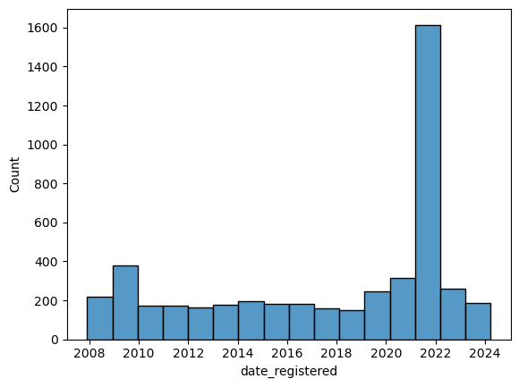

```python
# shape of date_registered
sns.histplot(df['date_registered'])
```

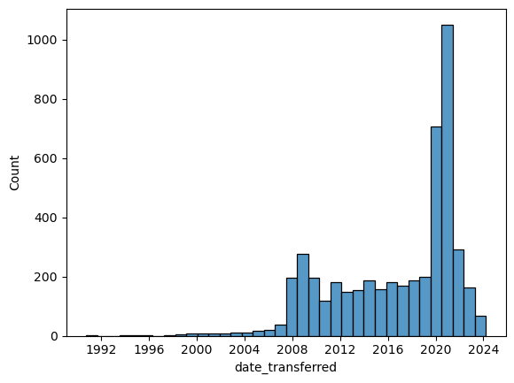

```python
# shape of date_transferred
sns.histplot(df['date_transferred'])
```

```python
df['registered-transfer'] = (df['date_registered'] - df['date_transferred']).dt.days / 365

df.sort_values('registered-transfer')
```

|  | transferor | transferee | date_transferred | date_registered | registered-transfer |
| --- | --- | --- | --- | --- | --- |
| 3716 | Town Land (258168) | Poor's Allotment (258167) | 2013-08-14 | 2012-08-14 | -1.000000 |
| 3627 | Wallace & Gromit's Children's Foundation (1096... | The Royal Hospital for Children Bristol Appeal... | 2014-03-31 | 2013-04-14 | -0.961644 |
| 2402 | City of London School Scholarships and Prizes ... | CLS Bursary and Awards Fund (276654) | 2020-12-22 | 2020-02-04 | -0.882192 |
| 4724 | The British Olympic Foundation (286106) | British Olympic Foundation (1122080) | 2008-12-09 | 2008-01-30 | -0.860274 |
| 2403 | The Stephens Collection (1051384) | Avenue House Estate Trust (1093908) | 2020-12-01 | 2020-02-03 | -0.827397 |
| ... | ... | ... | ... | ... | ... |
| 324 | CAMBRIDGESHIRE AND ISLE OF ELY NATURALISTS' TR... | THE WILDLIFE TRUST FOR BEDFORDSHIRE CAMBRIDGES... | 1990-10-12 | 2022-08-09 | 31.846575 |
| 2335 | The Lighting Education Trust (1051939) | Lighting Education Trust (1179394) | NaT | 2020-03-20 | NaN |
| 2412 | THE DEVONSHIRE AND DORSET REGIMENTAL ASSOCIATI... | THE DEVONSHIRE AND DORSET REGIMENTAL TRUST (11... | NaT | 2020-01-15 | NaN |
| 3156 | Hafod Y Wern Playgroup (1133002) | Caia Park Partnership (1072393) | NaT | 2015-11-24 | NaN |
| 3204 | The Noise Abatement Society (272040) | The Noise Abatement Society (1146192) | NaT | 2015-07-29 | NaN |

4772 rows × 5 columns

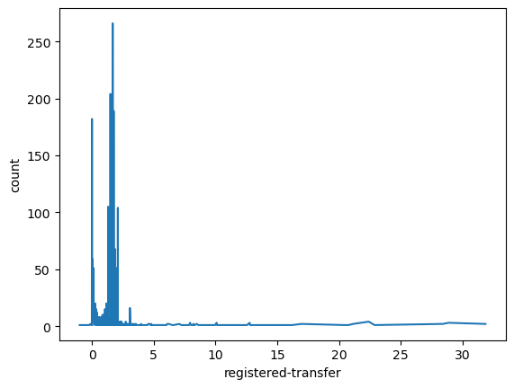

```python
sns.lineplot(
    data=df['registered-transfer'].value_counts().reset_index(),
    x='registered-transfer',
    y='count'
)
```

```python
chart_transfer = (
    alt.Chart(df['date_transferred'].to_frame())
    .mark_bar()
    .encode(
        alt.X('year(date_transferred):T'),
        alt.Y(
            'count():Q',
            title='count of records',
            scale=alt.Scale(domain=[-100, 1600])
        )
    )
)

chart_diff = (
    alt.Chart(df[['date_transferred', 'registered-transfer']])
    .mark_line(color='darkred')
    .encode(
        alt.X('year(date_transferred):T'),
        alt.Y(
            'registered-transfer:Q',
            axis=alt.Axis(
                title='date registered - date of transfer (years)',
                titleColor='darkred'
            ),
            scale=alt.Scale(domain=[-2.5, 35])
        )
    )
)

chart = (chart_transfer + chart_diff).resolve_scale(y='independent')

chart
```

[interactive chart not shown]

##### Extract charity numbers

```python
# check how charity numbers are indicated
df['transferor'].sample(50).str[-15:]
```

```
425     Trust (1106206)
4706    n Tyne (528069)
850     tnesses 1066609
4641     Trust (242773)
1686    tnesses 1066633
65       (UNREGISTERED)
1797    Fund 1053467.34
1055    tnesses 1065425
2604    icemen (209716)
1603    tnesses 1066448
4079    Trust (1095588)
3267    riends (252376)
158     TRUST (1001301)
175      TRUST (702502)
4123     Trust (234077)
```

[output cut: 36 more lines]

```python
# create charity number cols by extracting contents of last group in parentheses
# and filling any null values with any string of 5+ numbers
df['transferor_number'] = df['transferor'].str.lower().str.extract(
    pat='\(([^\(]+?)\)$'
)
df['transferor_number'] = df['transferor_number'].str.replace(pat='[\-\.\/]', repl='-')
df['transferor_number'] = df['transferor_number'].combine_first(
    df['transferor'].str.extract(pat='(\d{5,})')[0]
)

df['transferee_number'] = df['transferee'].str.lower().str.extract(
    pat='\(([^\(]+?)\)$'
)
df['transferee_number'] = df['transferee_number'].str.replace(pat='[\-\.\/]', repl='-')
df['transferee_number'] = df['transferee_number'].combine_first(
    df['transferee'].str.extract(pat='(\d{5,})')[0]
)
```

```python
# list values that are not charity numbers
df['transferor_number'].loc[
    ~df['transferor_number'].apply(str).str.contains(r'\d')
].value_counts()
```

```
transferor_number
unregistered                                       66
exempt charity                                     16
excepted charity                                    8
unregistered charity                                6
exempt                                              3
excepted                                            3
unincorporated                                      2
unregistered unincorporated charity                 2
unincorporated charity                              1
unrestricted assets only                            1
formerly known as mount zion evangelical church     1
all excepted                                        1
not registered                                      1
herne bay branch                                    1
bottley                                             1
mrs m gee trust                                     1
Name: count, dtype: int64
```

```python
# standardise values that are not charity numbers
df['transferor_number'] = df['transferor_number'].replace(
    to_replace={
        'unregistered .*': 'unregistered',
        'exempt .*': 'exempt',
        'excepted .*': 'excepted',
        'unincorporated .*': 'unincorporated',
        'not registered': 'unregistered',
    },
    regex=True
).replace(
    to_replace={
        value: 'other' for value in [
            'unrestricted assets only',
            'formerly known as mount zion evangelical church',
            'all excepted',
            'herne bay branch',
            'bottley',
            'mrs m gee trust',
        ]
    }
)

df['transferor_number'].loc[
    ~df['transferor_number'].apply(str).str.contains(r'\d')
].value_counts()
```

```
transferor_number
unregistered      75
exempt            19
excepted          12
other              6
unincorporated     3
Name: count, dtype: int64
```

```python
# list values that are not charity numbers
df['transferee_number'].loc[
    ~df['transferee_number'].apply(str).str.contains(r'\d')
].value_counts()
```

```
transferee_number
unregistered                         5
exempt charity                       4
incorporating the merrett bequest    1
cio                                  1
excepted                             1
picpus                               1
exempt                               1
Name: count, dtype: int64
```

```python
# standardise values that are not charity numbers
df['transferee_number'] = df['transferee_number'].replace(
    to_replace={
        'exempt charity': 'exempt',
        'incorporating the merrett bequest': 'other',
        'cio': 'other',
        'picpus': 'other',
    }
)

df['transferee_number'].loc[
    ~df['transferee_number'].apply(str).str.contains(r'\d')
].value_counts()
```

```
transferee_number
exempt          5
unregistered    5
other           3
excepted        1
Name: count, dtype: int64
```

#### Joining with `annual returns` data

```python
with open(
    '../data/publicextract.charity_annual_return_history.json', 'r', encoding='utf-8-sig'
) as file:
    data = json.load(file)

df_ar = pd.DataFrame(data)
```

```python
df_ar.head()
```

|  | date_of_extract | organisation_number | registered_charity_number | fin_period_start_date | fin_period_end_date | ar_cycle_reference | reporting_due_date | date_annual_return_received | date_accounts_received | total_gross_income | total_gross_expenditure | accounts_qualified | suppression_ind | suppression_type |
| --- | --- | --- | --- | --- | --- | --- | --- | --- | --- | --- | --- | --- | --- | --- |
| 0 | 2024-04-23T00:00:00 | 200001 | 200001 | 2008-10-01T00:00:00 | 2009-09-30T00:00:00 | AR09 | 2010-07-30T00:00:00 | 2010-07-30T00:00:00 | 2010-07-30T00:00:00 | 35270.0 | 35692.0 | None | False | None |
| 1 | 2024-04-23T00:00:00 | 200001 | 200001 | 2009-10-01T00:00:00 | 2010-09-30T00:00:00 | AR10 | 2011-07-30T00:00:00 | 2011-08-02T00:00:00 | 2011-08-02T00:00:00 | 84000.0 | 71849.0 | None | False | None |
| 2 | 2024-04-23T00:00:00 | 200001 | 200001 | 2010-10-01T00:00:00 | 2011-09-30T00:00:00 | AR11 | 2012-07-30T00:00:00 | None | None | NaN | NaN | None | False | None |
| 3 | 2024-04-23T00:00:00 | 200001 | 200001 | 2011-10-01T00:00:00 | 2012-09-30T00:00:00 | AR12 | 2013-07-30T00:00:00 | None | None | NaN | NaN | None | False | None |
| 4 | 2024-04-23T00:00:00 | 200001 | 200001 | 2012-10-01T00:00:00 | 2013-09-30T00:00:00 | AR13 | 2014-07-30T00:00:00 | None | None | NaN | NaN | None | False | None |

```python
df_ar = df_ar[[
    'date_of_extract',
    'registered_charity_number',
    'fin_period_start_date',
    'fin_period_end_date',
    'total_gross_income',
    'total_gross_expenditure',
]]
```

```python
df_ar.dtypes
```

```
date_of_extract               object
registered_charity_number      int64
fin_period_start_date         object
fin_period_end_date           object
total_gross_income           float64
total_gross_expenditure      float64
dtype: object
```

```python
date_cols = [
    'date_of_extract',
    'fin_period_start_date',
    'fin_period_end_date',
]

df_ar[date_cols] = df_ar[date_cols].apply(pd.to_datetime)

df_ar.head()
```

|  | date_of_extract | registered_charity_number | fin_period_start_date | fin_period_end_date | total_gross_income | total_gross_expenditure |
| --- | --- | --- | --- | --- | --- | --- |
| 0 | 2024-04-23 | 200001 | 2008-10-01 | 2009-09-30 | 35270.0 | 35692.0 |
| 1 | 2024-04-23 | 200001 | 2009-10-01 | 2010-09-30 | 84000.0 | 71849.0 |
| 2 | 2024-04-23 | 200001 | 2010-10-01 | 2011-09-30 | NaN | NaN |
| 3 | 2024-04-23 | 200001 | 2011-10-01 | 2012-09-30 | NaN | NaN |
| 4 | 2024-04-23 | 200001 | 2012-10-01 | 2013-09-30 | NaN | NaN |

```python
df_ar.dtypes
```

```
date_of_extract              datetime64[ns]
registered_charity_number             int64
fin_period_start_date        datetime64[ns]
fin_period_end_date          datetime64[ns]
total_gross_income                  float64
total_gross_expenditure             float64
dtype: object
```

```python
df_ar['fin_start_year'] = df_ar['fin_period_start_date'].dt.year
df_ar['fin_end_year'] = df_ar['fin_period_end_date'].dt.year
```

```python
df_ar.head()
```

|  | date_of_extract | registered_charity_number | fin_period_start_date | fin_period_end_date | total_gross_income | total_gross_expenditure | fin_start_year | fin_end_year |
| --- | --- | --- | --- | --- | --- | --- | --- | --- |
| 0 | 2024-04-23 | 200001 | 2008-10-01 | 2009-09-30 | 35270.0 | 35692.0 | 2008 | 2009 |
| 1 | 2024-04-23 | 200001 | 2009-10-01 | 2010-09-30 | 84000.0 | 71849.0 | 2009 | 2010 |
| 2 | 2024-04-23 | 200001 | 2010-10-01 | 2011-09-30 | NaN | NaN | 2010 | 2011 |
| 3 | 2024-04-23 | 200001 | 2011-10-01 | 2012-09-30 | NaN | NaN | 2011 | 2012 |
| 4 | 2024-04-23 | 200001 | 2012-10-01 | 2013-09-30 | NaN | NaN | 2012 | 2013 |

```python
df['merger_year'] = df['date_transferred'].dt.year
```

### Number of mergers over time

#### Most frequent transferors

```python
df['transferor_number'].value_counts()[:10].to_frame()
```

| transferor_number | count |
| --- | --- |
| unregistered | 75 |
| 1053467 | 31 |
| exempt | 19 |
| excepted | 12 |
| other | 6 |
| 1189059 | 5 |
| unincorporated | 3 |
| 1098026 | 2 |
| 1060621 | 2 |
| 1147851 | 2 |

The [Guidance about the register of merged charities](https://www.gov.uk/government/publications/register-of-merged-charities/guidance-about-the-register-of-merged-charities#different-types-of-merger) states:

> There are different types of merger:
> - merging with an existing charity
> - merging with a new charity you have set up for the purpose of merging
> - changing structure - usually a trust or unincorporated association that wants to change to a CIO or charitable company.

The prevalence of unregistered/exempt/excepted transferors probably indicates one of two things:

- Mergers of **very small charities (which are unregistered/exempt) officially joining bigger ones**. It's likely that these small charities are merging with larger ones to gain economies of scale, access to more resources, or to increase their impact. Alternatively, they might be facing hurdles due to funding constraints, regulatory burdens, or other challenges, and merging with a larger charity is a way to ensure their assets and mission continue.
- Mergers of charities into **a new structure (CIO or charitable company)**.

```python
transferor_freqs = df['transferor_number'].value_counts().value_counts().reset_index(name='freqs')

transferor_freqs = transferor_freqs.sort_values(by='count')

transferor_freqs
```

|  | count | freqs |
| --- | --- | --- |
| 0 | 1 | 4479 |
| 1 | 2 | 20 |
| 8 | 3 | 1 |
| 7 | 5 | 1 |
| 6 | 6 | 1 |
| 5 | 12 | 1 |
| 4 | 19 | 1 |
| 3 | 31 | 1 |
| 2 | 75 | 1 |

Most registered transferors have only been in the position of transferring charity once or twice.

This makes sense, since the transferor charity typically ceases to exist as a separate entity after the merger.

The outcomes of a merger, as stated by the [Guidance about the register of merged charities](https://www.gov.uk/government/publications/register-of-merged-charities/guidance-about-the-register-of-merged-charities#why-register):

> - your charity has closed or will close as a result of transferring your assets or
> - your charity has not closed only because it has permanent endowment which will not be transferred to the charity you are merging with

These repeat transferors might be falling into this second case.

```python
df[['transferor', 'transferee']].loc[df['transferor'].str.contains('1053467')].head()
```

|  | transferor | transferee |
| --- | --- | --- |
| 1767 | Accident and Emergency Charity (1053467.01) | The County Durham and Darlington NHS Foundatio... |
| 1768 | Anaesthetics Charity (1053467.02) | The County Durham and Darlington NHS Foundatio... |
| 1769 | Bequest of Robert Fidderman for the Darlington... | The County Durham and Darlington NHS Foundatio... |
| 1770 | Book of Remembrance Charity 1053467.25 | The County Durham and Darlington NHS Foundatio... |
| 1771 | Business Management Charity (1053467.03) | The County Durham and Darlington NHS Foundatio... |

*The County Durham and Darlington NHS Foundation Trust Charity* seems to be a case of a large consolidation.

A number of department-specific NHS charities have merged into one entity. The aim could be to consolidate funds/reduce administrative overhead/streamline operations.

```python
df['transferor'].value_counts()[:10]
```

```
transferor
The Parochial Church Council of the Ecclesiastical Parish of The A453 Churches of South Nottinghamshire (1189059)    5
Derbyshire Dales Crossroads Caring for Carers (1098026)                                                              2
Girl Norah                                                                                                           2
Signature Care and Support (1081081)                                                                                 2
South Leicestershire Crossroads Care Attendant Scheme (1062620)                                                      2
Broxtowe Crossroads Limited (1059082)                                                                                2
Positive Pete (1147851)                                                                                              2
The Chronic Granulomatous Disorder Research Trust (1003425)                                                          2
Wigan Advanced Motorists (518387)                                                                                    2
The Victorian Society (210707)                                                                                       2
Name: count, dtype: int64
```

```python
df.loc[df['transferor_number'] == '1189059'].iloc[:,:2].values
```

```
array([['The Parochial Church Council of the Ecclesiastical Parish of The A453 Churches of South Nottinghamshire (1189059)',
        'The Parochial Church Council of the Ecclesiastical Parish of All Saints, Thrumpton'],
       ['The Parochial Church Council of the Ecclesiastical Parish of The A453 Churches of South Nottinghamshire (1189059)',
        'The Parochial Church Council of the Ecclesiastical Parish of Holy Trinity, Ratcliffe-on-Soar'],
       ['The Parochial Church Council of the Ecclesiastical Parish of The A453 Churches of South Nottinghamshire (1189059)',
        'The Parochial Church Council of the Ecclesiastical Parish of St George, Barton-in-Fabis'],
       ['The Parochial Church Council of the Ecclesiastical Parish of The A453 Churches of South Nottinghamshire (1189059)',
        'The Parochial Church Council of the Ecclesiastical Parish of St Lawrence, Gotham'],
       ['The Parochial Church Council of the Ecclesiastical Parish of The A453 Churches of South Nottinghamshire (1189059)',
        'The Parochial Church Council of the Ecclesiastical Parish of St Winifred, Kingston-on-Soar']],
      dtype=object)
```

*The Parochial Church Council of the Ecclesiastical Parish of The A453 Churches of South Nottinghamshire* seems to be an example of a "merged" charity splitting into separate entities.

It is the most frequent transferor among registered charities, having been in that position 5 times.

While this seems to be a reverse merger, it could also be the parent charity distributing some assets to children charities.

#### Most frequent transferees

```python
df['transferee_number'].value_counts()[:10]
```

```
transferee_number
275946       1281
298028         70
212432         60
1053467        43
801465         40
1125485        35
1004630        17
1051649        16
210202-19      14
1122062        11
Name: count, dtype: int64
```

```python
transferee_freqs = df['transferee_number'].value_counts().value_counts().reset_index(name='freqs')

transferee_freqs = transferee_freqs.sort_values(by='count')

transferee_freqs
```

|  | count | freqs |
| --- | --- | --- |
| 0 | 1 | 2432 |
| 1 | 2 | 183 |
| 2 | 3 | 57 |
| 3 | 4 | 23 |
| 4 | 5 | 9 |
| 5 | 6 | 3 |
| 6 | 7 | 2 |
| 8 | 8 | 1 |
| 7 | 9 | 1 |
| 18 | 11 | 1 |
| 11 | 14 | 1 |
| 12 | 16 | 1 |
| 13 | 17 | 1 |
| 14 | 35 | 1 |
| 15 | 40 | 1 |
| 16 | 43 | 1 |
| 17 | 60 | 1 |
| 10 | 70 | 1 |
| 9 | 1281 | 1 |

```python
chart = (
    alt.Chart(transferee_freqs)
    .mark_bar()
    .encode(
        alt.X('count:Q'),
        alt.Y('freqs:Q')
    )
)

chart
```

[interactive chart not shown]

```
[]
```

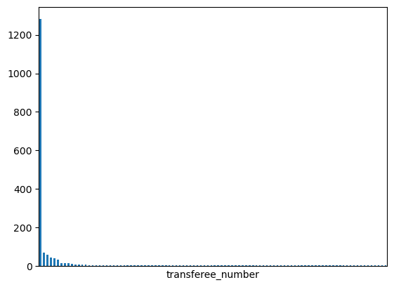

```python
df['transferee_number'].value_counts().iloc[:100].plot(kind='bar').set_xticks([])
```

Without counting the outlier that merged 1200+ times, some transferees have gone through mergers >40 times.

Most transferees only go through a merger <5 times.

```python
df['transferee'].value_counts()[:10]
```

```
transferee
The Kingdom Hall Trust 275946                                              1279
Victim Support (298028)                                                      70
The Mission to Seafarers (212432)                                            60
The County Durham and Darlington NHS Foundation Trust Charity (1053467)      43
The Merchant Taylors' Schools Crosby (1125485)                               35
Central Hardship and Relief Fund (801465)                                    20
Central Hardship and Relief Trust (CHART) (801465)                           18
UK Community Foundations (1004630)                                           16
Royal Artillery Benevolent Fund (210202-19)                                  14
Bauer Radio's Cash for Kids Charities (1122062)                              11
Name: count, dtype: int64
```

```python
df[['transferor', 'transferee']].loc[
    df['transferee'].str.contains('Kingdom Hall Trust')
].head()
```

|  | transferor | transferee |
| --- | --- | --- |
| 437 | Hull, Pearson Park Congregation of Jehovah's ... | The Kingdom Hall Trust 275946 |
| 453 | Aberaeron Congregation of Jehovah's Witnesses... | The Kingdom Hall Trust 275946 |
| 454 | Aberdare Congregation of Jehovah's Witnesses 2... | The Kingdom Hall Trust 275946 |
| 455 | Abergavenny Congregation of Jehovah's Witness... | The Kingdom Hall Trust 275946 |
| 456 | Abertillery Congregation of Jehovah's Witness... | The Kingdom Hall Trust 275946 |

```python
df[['transferor', 'transferee']].loc[
    df['transferee'].str.contains('Victim Support')
].head()
```

|  | transferor | transferee |
| --- | --- | --- |
| 4180 | Bromley Victim Support Scheme (1108399) | Victim Support (298028) |
| 4181 | Camden Victim Support (1054692) | Victim Support (298028) |
| 4182 | Lewisham Victim Support Scheme (1042159) | Victim Support (298028) |
| 4183 | Victim Support County Durham (1090221) | Victim Support (298028) |
| 4184 | Victim Support Devon (1088440) | Victim Support (298028) |

```python
df[['transferor', 'transferee']].loc[
    df['transferee'].str.contains('Mission to Seafarers')
].head()
```

|  | transferor | transferee |
| --- | --- | --- |
| 4415 | Ada Milligan | The Mission to Seafarers (212432) |
| 4416 | Agnes Jones Memorial Fund | The Mission to Seafarers (212432) |
| 4417 | Andrew McKee Memorial Fund | The Mission to Seafarers (212432) |
| 4418 | Annie Walker | The Mission to Seafarers (212432) |
| 4419 | ASM Harris | The Mission to Seafarers (212432) |

Summary from a [Brave](https://search.brave.com/search?q=The+Kingdom+Hall+Trust+&summary=1) search:

The Kingdom Hall Trust:

- Previously known as the London Company of Kingdom Witnesses, it was established on 28th July 1939 and changed its name to The Kingdom Hall Trust on 20th June 1994.
- It is a charity associated with Jehovah’s Witnesses, with the charity number GB-CHC-275946.
- The charity has undergone a significant merger in 2022, incorporating 1,279 Jehovah’s Witness congregations into the national charity. This is considered one of the largest charity mergers ever.

#### Count of mergers per year

```python
merger_counts = df.groupby(
    df['date_registered'].dt.year, as_index=True
)['date_registered'].count()

merger_counts = merger_counts.to_frame('count').reset_index()

merger_counts.T
```

|  | 0 | 1 | 2 | 3 | 4 | 5 | 6 | 7 | 8 | 9 | 10 | 11 | 12 | 13 | 14 | 15 | 16 | 17 |
| --- | --- | --- | --- | --- | --- | --- | --- | --- | --- | --- | --- | --- | --- | --- | --- | --- | --- | --- |
| date_registered | 2007 | 2008 | 2009 | 2010 | 2011 | 2012 | 2013 | 2014 | 2015 | 2016 | 2017 | 2018 | 2019 | 2020 | 2021 | 2022 | 2023 | 2024 |
| count | 9 | 227 | 375 | 166 | 166 | 163 | 166 | 198 | 163 | 185 | 170 | 130 | 239 | 301 | 293 | 1588 | 191 | 42 |

```python
chart = (
    alt.Chart(merger_counts)
    .mark_bar()
    .encode(
        alt.Y('date_registered:N', title=''),
        alt.X('count:Q', title=''),
        alt.Color('date_registered:N', legend=None, scale=alt.Scale(scheme='dark2')),
    )
    .properties(
        title='Mergers per year, 11/2007-03/2024',
        width=600
    )
)
chart
```

[interactive chart not shown]